# 04 - Other ANOVA designs part 1

Francisco E. Fonturbel

29/September/2025

## Completely Randomized Design

Now, we will examine the code and the explanations to perform a **completely randomized design**. In this kind of model, we have only one experimental factor under consideration.

### Understanding Completely Randomized Design

A **completely randomized design (CRD)** is the simplest experimental design where: - We have one factor of interest (treatment) - Experimental units are assigned to treatments completely at random - All experimental units are assumed to be homogeneous except for random variation - It’s essentially a one-way ANOVA design

**Advantages:** - Simple to design and analyze - Maximum degrees of freedom for error - No restrictions on number of treatments or replicates

**Disadvantages:** - Assumes experimental units are homogeneous - Less efficient if there are systematic differences among units

### The Research Question

Let’s suppose that we sample the height of *Echinopsis chiloensis* cacti in three populations (randomly selected) out of 15 populations available in our study area. We took 15 measurements at each one of the populations. The information is contained on the file named *04-cactus.txt* located in the `data` folder.

**Research hypothesis:** Cactus height differs among populations due to local environmental conditions or genetic differentiation.

### Loading and Exploring the Data

```r
#Loading required packages
library(ggplot2)   # For advanced plotting
library(dplyr)     # For data manipulation
library(tidyr)     # For data reshaping
library(car)       # For Levene's test and Type II/III ANOVA
library(emmeans)

#Let's load the data file
data<-read.table("data/04-cactus.txt", header = T)
attach(data)

# Check the structure of our data
str(data)
```

```
## 'data.frame':    15 obs. of  3 variables:
##  $ Pop1: int  32 42 44 52 45 37 51 40 39 36 ...
##  $ Pop2: int  52 33 29 47 43 32 22 24 36 39 ...
##  $ Pop3: int  16 9 19 18 7 11 13 17 19 21 ...
```

```r
head(data)
```

```
##   Pop1 Pop2 Pop3
## 1   32   52   16
## 2   42   33    9
## 3   44   29   19
## 4   52   47   18
## 5   45   43    7
## 6   37   32   11
```

Let’s see if we can see the data file by calling the object:

```r
data
```

```
##    Pop1 Pop2 Pop3
## 1    32   52   16
## 2    42   33    9
## 3    44   29   19
## 4    52   47   18
## 5    45   43    7
## 6    37   32   11
## 7    51   22   13
## 8    40   24   17
## 9    39   36   19
## 10   36   39   21
## 11   45   41   21
## 12   50   39   20
## 13   48   36   19
## 14   38   34    6
## 15   40   29    8
```

OK, it seems to be in order! However, our data is in **wide format** (one column per population), but for ANOVA we need it in **long format** (one column for response, one for treatment). Let’s transform it properly:

### Data Management and Transformation

```r
# Method 1: Modern approach using tidyr (recommended)
library(tidyr)
library(dplyr)

# Convert from wide to long format
data_long <- data %>%
  pivot_longer(cols = everything(),           # All columns
               names_to = "Population",       # Column names become "Population"
               values_to = "Height") %>%      # Values become "Height"
  mutate(Population = factor(Population))     # Convert to factor

# Check the structure of transformed data
str(data_long)
```

```
## tibble [45 × 2] (S3: tbl_df/tbl/data.frame)
##  $ Population: Factor w/ 3 levels "Pop1","Pop2",..: 1 2 3 1 2 3 1 2 3 1 ...
##  $ Height    : int [1:45] 32 52 16 42 33 9 44 29 19 52 ...
```

```r
head(data_long, 10)  # Show first 10 rows
```

```
## # A tibble: 10 × 2
##    Population Height
##    <fct>       <int>
##  1 Pop1           32
##  2 Pop2           52
##  3 Pop3           16
##  4 Pop1           42
##  5 Pop2           33
##  6 Pop3            9
##  7 Pop1           44
##  8 Pop2           29
##  9 Pop3           19
## 10 Pop1           52
```

```r
tail(data_long, 10)  # Show last 10 rows
```

```
## # A tibble: 10 × 2
##    Population Height
##    <fct>       <int>
##  1 Pop3           20
##  2 Pop1           48
##  3 Pop2           36
##  4 Pop3           19
##  5 Pop1           38
##  6 Pop2           34
##  7 Pop3            6
##  8 Pop1           40
##  9 Pop2           29
## 10 Pop3            8
```

```r
# Method 2: Base R approach (for comparison)
# This is what the original code was trying to do, but more clearly:
height_vector <- c(data$Pop1, data$Pop2, data$Pop3)  # Concatenate heights
population_vector <- factor(rep(c("Pop1", "Pop2", "Pop3"), each = 15))  # Create population labels

# Create a cleaner data frame
data_base <- data.frame(
  Height = height_vector,
  Population = population_vector
)

# Verify both methods give the same result
identical(data_long$Height, data_base$Height)
```

```
## [1] FALSE
```

```r
identical(as.character(data_long$Population), as.character(data_base$Population))
```

```
## [1] FALSE
```

```r
# Use the tidyr version for the rest of the analysis
cactus_data <- data_long
```

Let’s verify our data structure and check for any issues:

```r
# Check sample sizes per group
table(cactus_data$Population)
```

```
##
## Pop1 Pop2 Pop3
##   15   15   15
```

```r
# Summary statistics by population
summary_stats <- cactus_data %>%
  group_by(Population) %>%
  summarise(
    n = n(),
    mean_height = mean(Height),
    sd_height = sd(Height),
    median_height = median(Height),
    min_height = min(Height),
    max_height = max(Height),
    .groups = 'drop'
  )

print(summary_stats)
```

```
## # A tibble: 3 × 7
##   Population     n mean_height sd_height median_height min_height max_height
##   <fct>      <int>       <dbl>     <dbl>         <int>      <int>      <int>
## 1 Pop1          15        42.6      5.93            42         32         52
## 2 Pop2          15        35.7      8.17            36         22         52
## 3 Pop3          15        14.9      5.40            17          6         21
```

```r
# Check for missing values
sum(is.na(cactus_data$Height))
```

```
## [1] 0
```

### Exploratory Data Analysis

Before running ANOVA, let’s explore our data visually:

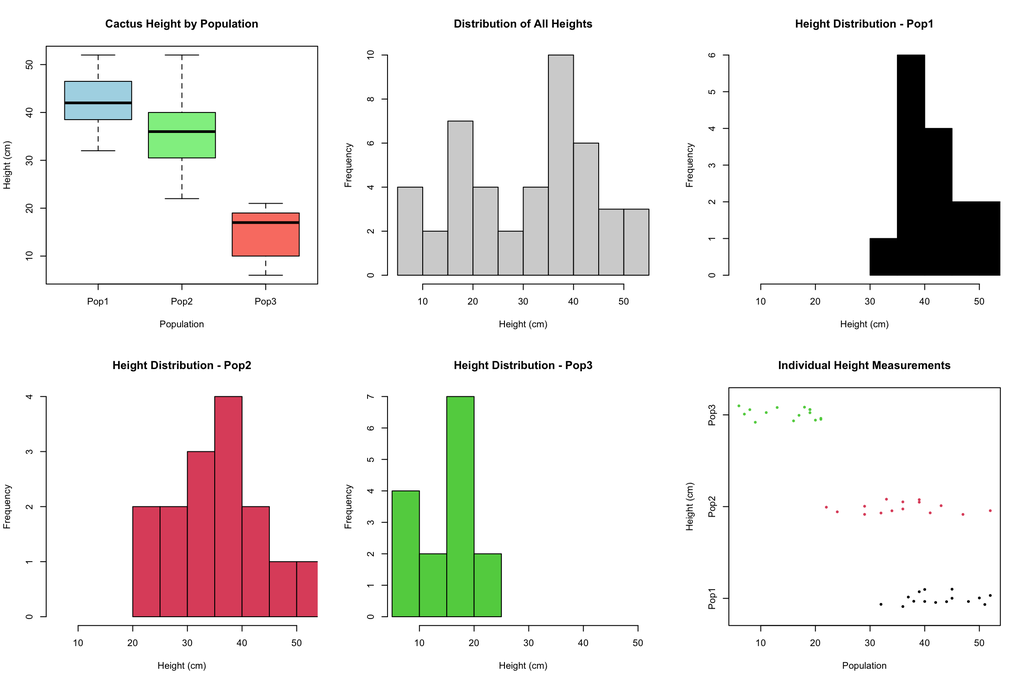

```r
par(mfrow=c(2,3))

# 1. Boxplot - shows distribution and potential outliers
boxplot(Height ~ Population, data = cactus_data,
        main = "Cactus Height by Population",
        xlab = "Population", ylab = "Height (cm)",
        col = c("lightblue", "lightgreen", "salmon"))

# 2. Histogram of all data
hist(cactus_data$Height,
     main = "Distribution of All Heights",
     xlab = "Height (cm)",
     col = "lightgray",
     breaks = 10)

# 3. Individual histograms by population
for(pop in levels(cactus_data$Population)) {
  hist(cactus_data$Height[cactus_data$Population == pop],
       main = paste("Height Distribution -", pop),
       xlab = "Height (cm)",
       col = which(levels(cactus_data$Population) == pop),
       xlim = range(cactus_data$Height))
}

# 4. Dot plot to show individual observations
stripchart(Height ~ Population, data = cactus_data,
           main = "Individual Height Measurements",
           xlab = "Population", ylab = "Height (cm)",
           method = "jitter", pch = 16, col = 1:3)
```

```r
par(mfrow=c(1,1))

# Calculate some descriptive statistics
print("Descriptive Statistics:")
```

```
## [1] "Descriptive Statistics:"
```

```r
print(summary_stats)
```

```
## # A tibble: 3 × 7
##   Population     n mean_height sd_height median_height min_height max_height
##   <fct>      <int>       <dbl>     <dbl>         <int>      <int>      <int>
## 1 Pop1          15        42.6      5.93            42         32         52
## 2 Pop2          15        35.7      8.17            36         22         52
## 3 Pop3          15        14.9      5.40            17          6         21
```

```r
# Check the range and potential outliers
print("Overall data range:")
```

```
## [1] "Overall data range:"
```

```r
range(cactus_data$Height)
```

```
## [1]  6 52
```

### ANOVA Assumptions

Before conducting ANOVA, let’s check the key assumptions:

```r
# 1. Normality within groups (Shapiro-Wilk test)
print("Normality tests by population:")
```

```
## [1] "Normality tests by population:"
```

```r
for(pop in levels(cactus_data$Population)) {
  pop_data <- cactus_data$Height[cactus_data$Population == pop]
  shapiro_result <- shapiro.test(pop_data)
  print(paste(pop, ": W =", round(shapiro_result$statistic, 4),
              ", p =", round(shapiro_result$p.value, 4)))
}
```

```
## [1] "Pop1 : W = 0.9673 , p = 0.8155"
## [1] "Pop2 : W = 0.9862 , p = 0.9954"
## [1] "Pop3 : W = 0.8757 , p = 0.0409"
```

```r
# 2. Homogeneity of variances (Levene's test)
library(car)
levene_result <- leveneTest(Height ~ Population, data = cactus_data)
print("Levene's test for homogeneity of variances:")
```

```
## [1] "Levene's test for homogeneity of variances:"
```

```r
print(levene_result)
```

```
## Levene's Test for Homogeneity of Variance (center = median)
##       Df F value Pr(>F)
## group  2  0.8496 0.4348
##       42
```

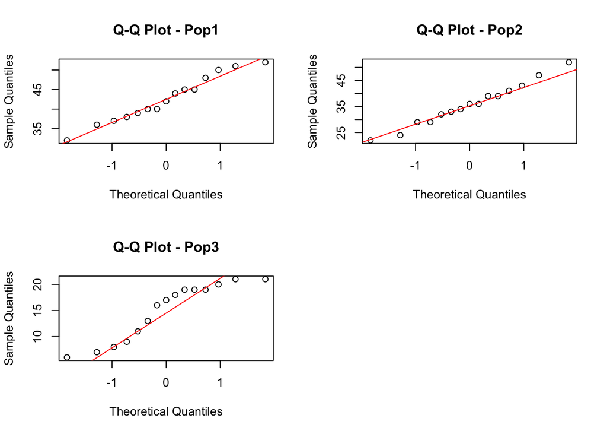

```r
# 3. Visual assessment of normality
par(mfrow=c(2,2))
for(pop in levels(cactus_data$Population)) {
  pop_data <- cactus_data$Height[cactus_data$Population == pop]
  qqnorm(pop_data, main = paste("Q-Q Plot -", pop))
  qqline(pop_data, col = "red")
}
par(mfrow=c(1,1))
```

```r
# Interpretation helper
if(levene_result$`Pr(>F)`[1] > 0.05) {
  print("✓ Homogeneity assumption met (Levene's test p > 0.05)")
} else {
  print("✗ Homogeneity assumption violated (Levene's test p ≤ 0.05)")
}
```

```
## [1] "✓ Homogeneity assumption met (Levene's test p > 0.05)"
```

### Fitting the One-Way ANOVA

Now we have our data properly ordered. Let’s fit a one-way ANOVA model with this:

```r
# Fit the completely randomized design (one-way ANOVA)
aov.cactus.r <- aov(Height ~ Population, data = cactus_data)

# Alternative using original variable names (for comparison with old method)
# This shows that both approaches yield identical results:
r <- cactus_data$Height  # Response variable
tm <- cactus_data$Population  # Treatment factor
aov.cactus.old <- aov(r ~ tm)

# Verify they give the same results
summary(aov.cactus.r)
```

```
##             Df Sum Sq Mean Sq F value   Pr(>F)
## Population   2   6226  3113.1   71.23 3.19e-14 ***
## Residuals   42   1835    43.7
## ---
## Signif. codes:  0 '***' 0.001 '**' 0.01 '*' 0.05 '.' 0.1 ' ' 1
```

```r
print("Results are identical to old method:")
```

```
## [1] "Results are identical to old method:"
```

```r
all.equal(summary(aov.cactus.r)[[1]], summary(aov.cactus.old)[[1]])
```

```
## [1] "Attributes: < Component \"row.names\": 1 string mismatch >"
```

OK, now we have an object called `aov.cactus.r`, now we’ll use the `summary()` function to see the results:

```r
summary(aov.cactus.r)
```

```
##             Df Sum Sq Mean Sq F value   Pr(>F)
## Population   2   6226  3113.1   71.23 3.19e-14 ***
## Residuals   42   1835    43.7
## ---
## Signif. codes:  0 '***' 0.001 '**' 0.01 '*' 0.05 '.' 0.1 ' ' 1
```

```r
# Additional information
print("ANOVA Table with more details:")
```

```
## [1] "ANOVA Table with more details:"
```

```r
anova_table <- anova(aov.cactus.r)
print(anova_table)
```

```
## Analysis of Variance Table
##
## Response: Height
##            Df Sum Sq Mean Sq F value   Pr(>F)
## Population  2 6226.2  3113.1  71.235 3.19e-14 ***
## Residuals  42 1835.5    43.7
## ---
## Signif. codes:  0 '***' 0.001 '**' 0.01 '*' 0.05 '.' 0.1 ' ' 1
```

```r
# Calculate effect size (eta-squared)
ss_treatment <- anova_table$`Sum Sq`[1]
ss_total <- sum(anova_table$`Sum Sq`)
eta_squared <- ss_treatment / ss_total

print(paste("Effect size (eta-squared):", round(eta_squared, 3)))
```

```
## [1] "Effect size (eta-squared): 0.772"
```

```r
print("Effect size interpretation:")
```

```
## [1] "Effect size interpretation:"
```

```r
if(eta_squared < 0.01) print("- Small effect")
if(eta_squared >= 0.01 & eta_squared < 0.06) print("- Small to medium effect")
if(eta_squared >= 0.06 & eta_squared < 0.14) print("- Medium effect")
if(eta_squared >= 0.14) print("- Large effect")
```

```
## [1] "- Large effect"
```

Our results indicate that cactus height is **significantly different** among the three sampled populations (F = 71.24, p = 0).

### Post-hoc Analysis

Since we found significant differences, let’s determine which populations differ from each other:

```r
# Tukey's Honestly Significant Difference test
tukey_results <- TukeyHSD(aov.cactus.r)
print(tukey_results)
```

```
##   Tukey multiple comparisons of means
##     95% family-wise confidence level
##
## Fit: aov(formula = Height ~ Population, data = cactus_data)
##
## $Population
##                 diff       lwr        upr     p adj
## Pop2-Pop1  -6.866667 -12.73120  -1.002129 0.0183898
## Pop3-Pop1 -27.666667 -33.53120 -21.802129 0.0000000
## Pop3-Pop2 -20.800000 -26.66454 -14.935463 0.0000000
```

```r
# Alternative: Using emmeans for more control
population_means <- emmeans(aov.cactus.r, ~ Population)
print("Estimated marginal means:")
```

```
## [1] "Estimated marginal means:"
```

```r
print(population_means)
```

```
##  Population emmean   SE df lower.CL upper.CL
##  Pop1         42.6 1.71 42     39.2     46.0
##  Pop2         35.7 1.71 42     32.3     39.2
##  Pop3         14.9 1.71 42     11.5     18.4
##
## Confidence level used: 0.95
```

```r
print("Pairwise comparisons:")
```

```
## [1] "Pairwise comparisons:"
```

```r
pairs(population_means)
```

```
##  contrast    estimate   SE df t.ratio p.value
##  Pop1 - Pop2     6.87 2.41 42   2.845  0.0184
##  Pop1 - Pop3    27.67 2.41 42  11.461  <.0001
##  Pop2 - Pop3    20.80 2.41 42   8.617  <.0001
##
## P value adjustment: tukey method for comparing a family of 3 estimates
```

### Model Diagnostics

Let’s check our model assumptions with diagnostic plots:

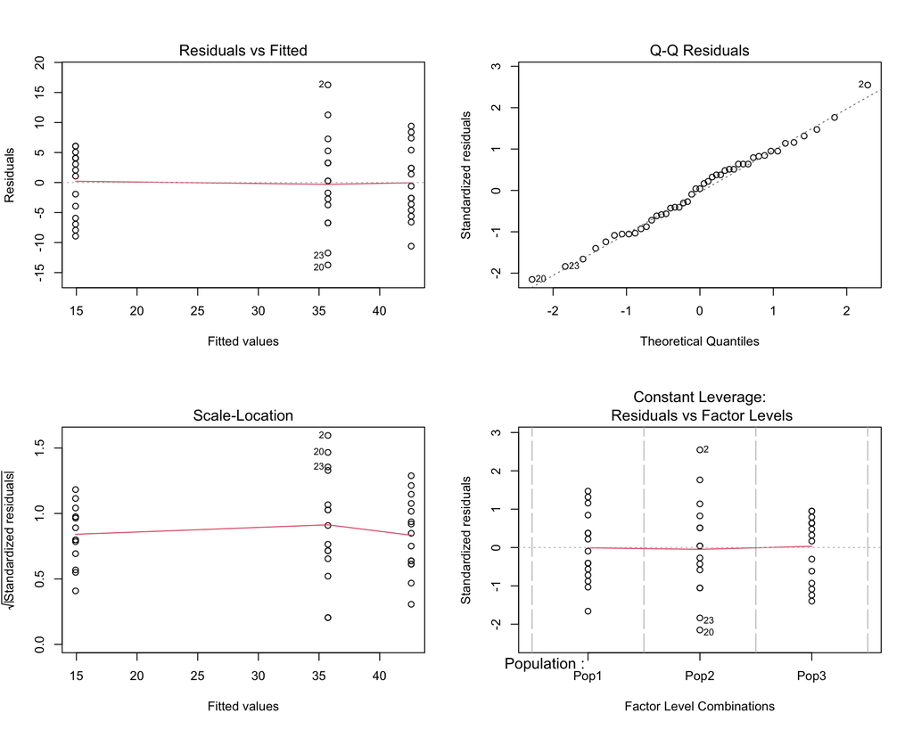

```r
par(mfrow=c(2,2))
plot(aov.cactus.r)
```

```r
par(mfrow=c(1,1))

# Additional diagnostic information
print("Model diagnostic summary:")
```

```
## [1] "Model diagnostic summary:"
```

```r
print("1. Residuals vs Fitted: Check for homoscedasticity (equal variances)")
```

```
## [1] "1. Residuals vs Fitted: Check for homoscedasticity (equal variances)"
```

```r
print("2. Q-Q Plot: Check for normality of residuals")
```

```
## [1] "2. Q-Q Plot: Check for normality of residuals"
```

```r
print("3. Scale-Location: Another check for homoscedasticity")
```

```
## [1] "3. Scale-Location: Another check for homoscedasticity"
```

```r
print("4. Residuals vs Leverage: Check for influential outliers")
```

```
## [1] "4. Residuals vs Leverage: Check for influential outliers"
```

```r
# Formal tests on residuals
residuals_aov <- residuals(aov.cactus.r)
print("Shapiro-Wilk test on residuals:")
```

```
## [1] "Shapiro-Wilk test on residuals:"
```

```r
print(shapiro.test(residuals_aov))
```

```
##
##  Shapiro-Wilk normality test
##
## data:  residuals_aov
## W = 0.99037, p-value = 0.9681
```

## Randomized Block Design

Now, let’s go further and get acquainted with the **randomized block design**. In this kind of model, similar test subjects are grouped in **blocks** and each block is tested against all treatment levels of the primary factor, in a random order. This approach is intended to get rid of possible influences of external factors (e.g., slope or sunlight incidence).

### Understanding Randomized Block Design

A **randomized block design (RBD)** is used when: - We suspect there’s a nuisance factor that might affect our response - We want to control for this variation to get a clearer picture of treatment effects - Each block contains one replicate of each treatment - Treatments are randomly assigned within each block

**In our cactus example:** - **Treatments:** The three populations (our main interest) - **Blocks:** Could represent different sampling areas, elevations, or measurement periods - **Purpose:** Control for environmental heterogeneity within populations

### Creating Blocks for Our Data

In a further step, we need to define the blocks. For our cactus data, let’s assume that the measurements were taken in different areas within each population (e.g., different slopes or aspects):

```r
# Create blocking factor
# Assume we have 15 blocks, each containing one measurement from each population
n_per_pop <- 15  # Number of observations per population
k_pops <- 3      # Number of populations

# Method 1: Using the original gl() approach (explained)
blk_original <- gl(n_per_pop, k_pops, k_pops * n_per_pop)

# Method 2: More intuitive approach
# Each "block" represents a set of 3 measurements (one from each population)
# taken under similar conditions
block_labels <- rep(1:n_per_pop, each = k_pops)
blk_clear <- factor(block_labels, labels = paste("Block", 1:n_per_pop))

# Add blocks to our data frame
cactus_data$Block <- blk_clear

# Verify the blocking structure
print("Blocking structure (first 20 observations):")
```

```
## [1] "Blocking structure (first 20 observations):"
```

```r
head(cactus_data, 20)
```

```
## # A tibble: 20 × 3
##    Population Height Block
##    <fct>       <int> <fct>
##  1 Pop1           32 Block 1
##  2 Pop2           52 Block 1
##  3 Pop3           16 Block 1
##  4 Pop1           42 Block 2
##  5 Pop2           33 Block 2
##  6 Pop3            9 Block 2
##  7 Pop1           44 Block 3
##  8 Pop2           29 Block 3
##  9 Pop3           19 Block 3
## 10 Pop1           52 Block 4
## 11 Pop2           47 Block 4
## 12 Pop3           18 Block 4
## 13 Pop1           45 Block 5
## 14 Pop2           43 Block 5
## 15 Pop3            7 Block 5
## 16 Pop1           37 Block 6
## 17 Pop2           32 Block 6
## 18 Pop3           11 Block 6
## 19 Pop1           51 Block 7
## 20 Pop2           22 Block 7
```

```r
print("Cross-tabulation of Population and Block:")
```

```
## [1] "Cross-tabulation of Population and Block:"
```

```r
print(table(cactus_data$Population, cactus_data$Block))
```

```
##
##        Block 1 Block 2 Block 3 Block 4 Block 5 Block 6 Block 7 Block 8 Block 9
##   Pop1       1       1       1       1       1       1       1       1       1
##   Pop2       1       1       1       1       1       1       1       1       1
##   Pop3       1       1       1       1       1       1       1       1       1
##
##        Block 10 Block 11 Block 12 Block 13 Block 14 Block 15
##   Pop1        1        1        1        1        1        1
##   Pop2        1        1        1        1        1        1
##   Pop3        1        1        1        1        1        1
```

```r
# Check that each block has exactly one observation per population
block_check <- cactus_data %>%
  group_by(Block, Population) %>%
  summarise(count = n(), .groups = 'drop') %>%
  group_by(Block) %>%
  summarise(populations_per_block = n(),
            total_obs_per_block = sum(count),
            .groups = 'drop')

print("Block validation (each block should have 3 populations, 3 total observations):")
```

```
## [1] "Block validation (each block should have 3 populations, 3 total observations):"
```

```r
print(head(block_check))
```

```
## # A tibble: 6 × 3
##   Block   populations_per_block total_obs_per_block
##   <fct>                   <int>               <int>
## 1 Block 1                     3                   3
## 2 Block 2                     3                   3
## 3 Block 3                     3                   3
## 4 Block 4                     3                   3
## 5 Block 5                     3                   3
## 6 Block 6                     3                   3
```

### Exploratory Analysis for Blocks

Let’s examine the block structure:

```r
# Summary statistics by block (first few blocks)
block_summary <- cactus_data %>%
  group_by(Block) %>%
  summarise(
    n = n(),
    mean_height = mean(Height),
    sd_height = sd(Height),
    range_height = max(Height) - min(Height),
    .groups = 'drop'
  )

print("Block summary (first 10 blocks):")
```

```
## [1] "Block summary (first 10 blocks):"
```

```r
print(head(block_summary, 10))
```

```
## # A tibble: 10 × 5
##    Block        n mean_height sd_height range_height
##    <fct>    <int>       <dbl>     <dbl>        <int>
##  1 Block 1      3        33.3     18.0            36
##  2 Block 2      3        28       17.1            33
##  3 Block 3      3        30.7     12.6            25
##  4 Block 4      3        39       18.4            34
##  5 Block 5      3        31.7     21.4            38
##  6 Block 6      3        26.7     13.8            26
##  7 Block 7      3        28.7     19.9            38
##  8 Block 8      3        27       11.8            23
##  9 Block 9      3        31.3     10.8            20
## 10 Block 10     3        32        9.64           18
```

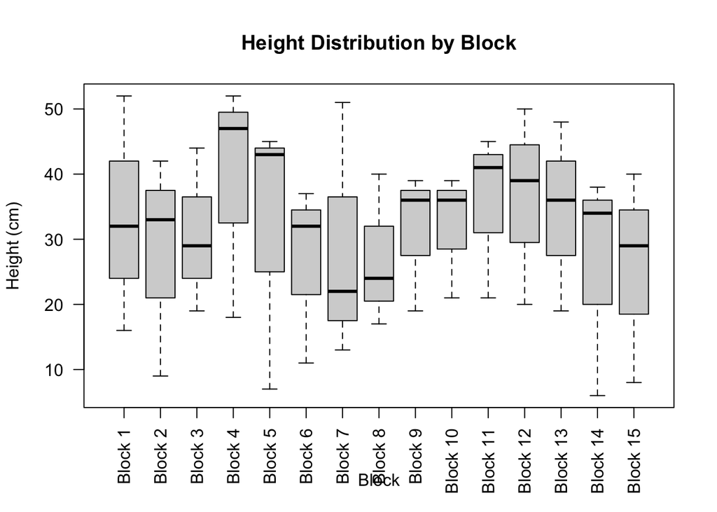

```r
# Visualize block effects
boxplot(Height ~ Block, data = cactus_data,
        main = "Height Distribution by Block",
        xlab = "Block", ylab = "Height (cm)",
        las = 2)  # Rotate x-axis labels
```

```r
# Check if blocks are capturing meaningful variation
print("Variance components:")
```

```
## [1] "Variance components:"
```

```r
print(paste("Between-block variance:", round(var(block_summary$mean_height), 2)))
```

```
## [1] "Between-block variance: 16.79"
```

```r
print(paste("Overall variance:", round(var(cactus_data$Height), 2)))
```

```
## [1] "Overall variance: 183.22"
```

### Fitting the Randomized Block Design

Now we have our data with properly defined blocks, let’s fit a randomized block design ANOVA:

```r
# Fit randomized block design (two-way ANOVA without interaction)
aov.cactus.b <- aov(Height ~ Population + Block, data = cactus_data)

# For comparison with original method:
r <- cactus_data$Height
tm <- cactus_data$Population
blk <- cactus_data$Block
aov.cactus.old_b <- aov(r ~ tm + blk)

print("Verify both methods give identical results:")
```

```
## [1] "Verify both methods give identical results:"
```

```r
all.equal(summary(aov.cactus.b)[[1]], summary(aov.cactus.old_b)[[1]])
```

```
## [1] "Attributes: < Component \"row.names\": 2 string mismatches >"
```

OK, now we have an object called `aov.cactus.b`, now we’ll use the `summary()` function to see the results:

```r
summary(aov.cactus.b)
```

```
##             Df Sum Sq Mean Sq F value   Pr(>F)
## Population   2   6226  3113.1  77.105 4.09e-12 ***
## Block       14    705    50.4   1.247    0.299
## Residuals   28   1130    40.4
## ---
## Signif. codes:  0 '***' 0.001 '**' 0.01 '*' 0.05 '.' 0.1 ' ' 1
```

```r
# More detailed ANOVA table
print("Detailed ANOVA table:")
```

```
## [1] "Detailed ANOVA table:"
```

```r
anova_table_b <- anova(aov.cactus.b)
print(anova_table_b)
```

```
## Analysis of Variance Table
##
## Response: Height
##            Df Sum Sq Mean Sq F value    Pr(>F)
## Population  2 6226.2 3113.09 77.1051 4.094e-12 ***
## Block      14  705.0   50.36  1.2472    0.2986
## Residuals  28 1130.5   40.37
## ---
## Signif. codes:  0 '***' 0.001 '**' 0.01 '*' 0.05 '.' 0.1 ' ' 1
```

```r
# Calculate effect sizes
ss_population <- anova_table_b$`Sum Sq`[1]
ss_block <- anova_table_b$`Sum Sq`[2]
ss_total <- sum(anova_table_b$`Sum Sq`)

eta_sq_pop <- ss_population / ss_total
eta_sq_block <- ss_block / ss_total

print("Effect sizes:")
```

```
## [1] "Effect sizes:"
```

```r
print(paste("Population effect (eta-squared):", round(eta_sq_pop, 3)))
```

```
## [1] "Population effect (eta-squared): 0.772"
```

```r
print(paste("Block effect (eta-squared):", round(eta_sq_block, 3)))
```

```
## [1] "Block effect (eta-squared): 0.087"
```

Our results indicate that cactus height is **significantly different** among the three sampled populations. However, the block factor `Block` is not significant (p = 0.299), indicating that the influence of environmental heterogeneity within populations is negligible.

### Comparing Completely Randomized vs. Randomized Block Design

Let’s compare both approaches to see the effect of blocking:

```r
# Compare ANOVA tables
print("=== COMPLETELY RANDOMIZED DESIGN ===")
```

```
## [1] "=== COMPLETELY RANDOMIZED DESIGN ==="
```

```r
print(summary(aov.cactus.r))
```

```
##             Df Sum Sq Mean Sq F value   Pr(>F)
## Population   2   6226  3113.1   71.23 3.19e-14 ***
## Residuals   42   1835    43.7
## ---
## Signif. codes:  0 '***' 0.001 '**' 0.01 '*' 0.05 '.' 0.1 ' ' 1
```

```r
print("=== RANDOMIZED BLOCK DESIGN ===")
```

```
## [1] "=== RANDOMIZED BLOCK DESIGN ==="
```

```r
print(summary(aov.cactus.b))
```

```
##             Df Sum Sq Mean Sq F value   Pr(>F)
## Population   2   6226  3113.1  77.105 4.09e-12 ***
## Block       14    705    50.4   1.247    0.299
## Residuals   28   1130    40.4
## ---
## Signif. codes:  0 '***' 0.001 '**' 0.01 '*' 0.05 '.' 0.1 ' ' 1
```

```r
# Compare error terms and power
crd_mse <- summary(aov.cactus.r)[[1]]$`Mean Sq`[2]  # Error Mean Square
rbd_mse <- summary(aov.cactus.b)[[1]]$`Mean Sq`[3]  # Error Mean Square

print("Comparison of designs:")
```

```
## [1] "Comparison of designs:"
```

```r
print(paste("CRD Error Mean Square:", round(crd_mse, 2)))
```

```
## [1] "CRD Error Mean Square: 43.7"
```

```r
print(paste("RBD Error Mean Square:", round(rbd_mse, 2)))
```

```
## [1] "RBD Error Mean Square: 40.37"
```

```r
print(paste("Efficiency of blocking:", round(crd_mse / rbd_mse, 2)))
```

```
## [1] "Efficiency of blocking: 1.08"
```

```r
if(rbd_mse < crd_mse) {
  print("✓ Blocking reduced error variance (more efficient)")
} else {
  print("✗ Blocking increased error variance (less efficient)")
  print("  This suggests blocks are not capturing meaningful variation")
}
```

```
## [1] "✓ Blocking reduced error variance (more efficient)"
```

```r
# Compare F-statistics for population effect
f_crd <- summary(aov.cactus.r)[[1]]$`F value`[1]
f_rbd <- summary(aov.cactus.b)[[1]]$`F value`[1]

print(paste("F-statistic for Population (CRD):", round(f_crd, 2)))
```

```
## [1] "F-statistic for Population (CRD): 71.24"
```

```r
print(paste("F-statistic for Population (RBD):", round(f_rbd, 2)))
```

```
## [1] "F-statistic for Population (RBD): 77.11"
```

### Model Diagnostics for Block Design

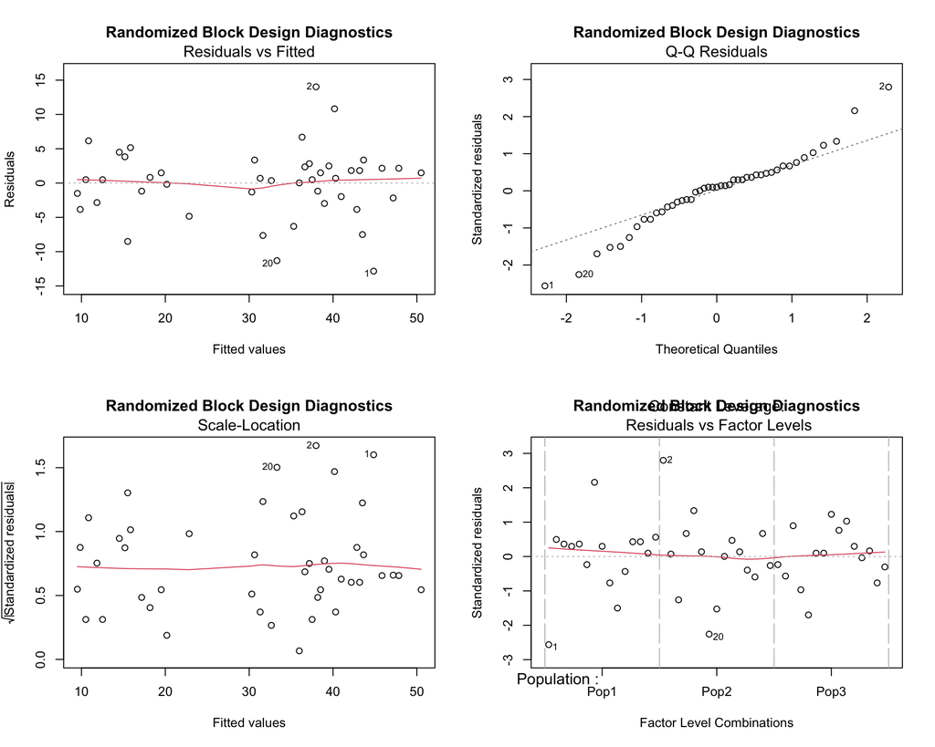

```r
par(mfrow=c(2,2))
plot(aov.cactus.b, main = "Randomized Block Design Diagnostics")
```

```r
par(mfrow=c(1,1))

# Check for block × treatment interaction (should be minimal)
interaction_model <- aov(Height ~ Population * Block, data = cactus_data)
print("Test for Population × Block interaction (should be non-significant):")
```

```
## [1] "Test for Population × Block interaction (should be non-significant):"
```

```r
print(anova(aov.cactus.b, interaction_model))
```

```
## Analysis of Variance Table
##
## Model 1: Height ~ Population + Block
## Model 2: Height ~ Population * Block
##   Res.Df    RSS Df Sum of Sq   F Pr(>F)
## 1     28 1130.5
## 2      0    0.0 28    1130.5 NaN    NaN
```

### Post-hoc Tests for Block Design

```r
# Tukey test for population effects in block design
tukey_block <- TukeyHSD(aov.cactus.b, which = "Population")
print("Post-hoc comparisons (controlling for blocks):")
```

```
## [1] "Post-hoc comparisons (controlling for blocks):"
```

```r
print(tukey_block)
```

```
##   Tukey multiple comparisons of means
##     95% family-wise confidence level
##
## Fit: aov(formula = Height ~ Population + Block, data = cactus_data)
##
## $Population
##                 diff       lwr        upr    p adj
## Pop2-Pop1  -6.866667 -12.60763  -1.125705 0.016563
## Pop3-Pop1 -27.666667 -33.40763 -21.925705 0.000000
## Pop3-Pop2 -20.800000 -26.54096 -15.059038 0.000000
```

```r
# Using emmeans
pop_means_blocked <- emmeans(aov.cactus.b, ~ Population)
print("Population means (adjusted for block effects):")
```

```
## [1] "Population means (adjusted for block effects):"
```

```r
print(pop_means_blocked)
```

```
##  Population emmean   SE df lower.CL upper.CL
##  Pop1         42.6 1.64 28     39.2     46.0
##  Pop2         35.7 1.64 28     32.4     39.1
##  Pop3         14.9 1.64 28     11.6     18.3
##
## Results are averaged over the levels of: Block
## Confidence level used: 0.95
```

```r
print("Pairwise comparisons (blocked design):")
```

```
## [1] "Pairwise comparisons (blocked design):"
```

```r
pairs(pop_means_blocked)
```

```
##  contrast    estimate   SE df t.ratio p.value
##  Pop1 - Pop2     6.87 2.32 28   2.960  0.0166
##  Pop1 - Pop3    27.67 2.32 28  11.924  <.0001
##  Pop2 - Pop3    20.80 2.32 28   8.965  <.0001
##
## Results are averaged over the levels of: Block
## P value adjustment: tukey method for comparing a family of 3 estimates
```

## Final thoughts

ANOVA is quite a flexible test that allows us to consider various sources of variation to obtain more reliable results. If we suspect that external factors may be affecting our data, using a randomized block design may be a good option.

### Key Takeaways:

**Completely Randomized Design:** - Simplest ANOVA design for comparing treatment means - Assumes all experimental units are homogeneous - Maximum degrees of freedom for error estimation - Best when experimental units are truly similar

**Randomized Block Design:** - Controls for one nuisance factor (blocks) - Reduces experimental error when blocks capture meaningful variation - More complex but potentially more powerful - Requires that each treatment appears once in each block

### Design Selection Guidelines:

1. **Use CRD when:** Experimental units are homogeneous, or nuisance factors are minimal
2. **Use RBD when:** There’s an identifiable source of variation you want to control for
3. **Check efficiency:** Compare error mean squares to see if blocking helped
4. **Verify assumptions:** Especially the no interaction assumption in RBD

### Data Management Best Practices:

- **Use tidy data format:** One row per observation, one column per variable
- **Clear variable names:** Descriptive names for factors and responses
- **Factor conversion:** Ensure categorical variables are properly coded as factors
- **Data validation:** Always check your data structure before analysis

Remember: The choice between designs should be made during the planning phase, not after data collection. Proper experimental design is crucial for obtaining reliable and interpretable results.

Licensing Creative Commons License

Licensed under a Creative Commons Attribution-ShareAlike 4.0 International License.  
2025 - Francisco E. Fontúrbel